# EDA Assiginment 9

Motoki Sugino

11/25/2016

#### The U.S. News and World Report magazine ranks colleges every year using a variety of criteria. The dataset college.ratings in the LearnEDA package gives statistics for 225 “National Universities” (including BGSU). Note that the universities are grouped into four tiers { Tier 1 are the best rated schools for undergraduates, Tier 2 is the group of next-best schools, and so on. (BGSU is rated in the third tier.)

#### 1. Consider the fraction variable a.grad.rate (percentage of freshmen who graduated within a six-year period). Compare the fraction variable across tiers and also compare the froots of the variable across tiers and also compare the flogs of the variable across tiers. Is it necessary to reexpress the data by froots or flogs in this example? Explain.

**Comparing the fraction variable across tiers.**

```r
library(LearnEDA)
head(college.ratings)
```

```
##                               School Tier    Type Reputation F.retention
## 1               Princeton_University    1 private        4.9        0.99
## 2                 Harvard_University    1 private        4.9        0.96
## 3                    Yale_University    1 private        4.9        0.98
## 4 California_Institute_of_Technology    1 private        4.7        0.94
## 5  Massachusetts_Inst._of_Technology    1 private        4.9        0.98
## 6                Stanford_University    1 private        4.9        0.98
##   a.grad.rate Under.20 Over.50 Full.time Top.10 Acc.rate Alum.giving
## 1        0.97     0.71    0.11      0.92   0.92     0.12        0.66
## 2        0.97     0.69    0.13      0.91   0.90     0.11        0.46
## 3        0.95     0.75    0.08      0.90   0.95     0.16        0.46
## 4        0.82     0.76    0.05      0.96   0.98     0.13        0.39
## 5        0.91     0.58    0.16      0.89   0.97     0.16        0.41
## 6        0.93     0.69    0.14      0.99   0.89     0.13        0.40
```

```r
head(college.ratings$a.grad.rate)
```

```
## [1] 0.97 0.97 0.95 0.82 0.91 0.93
```

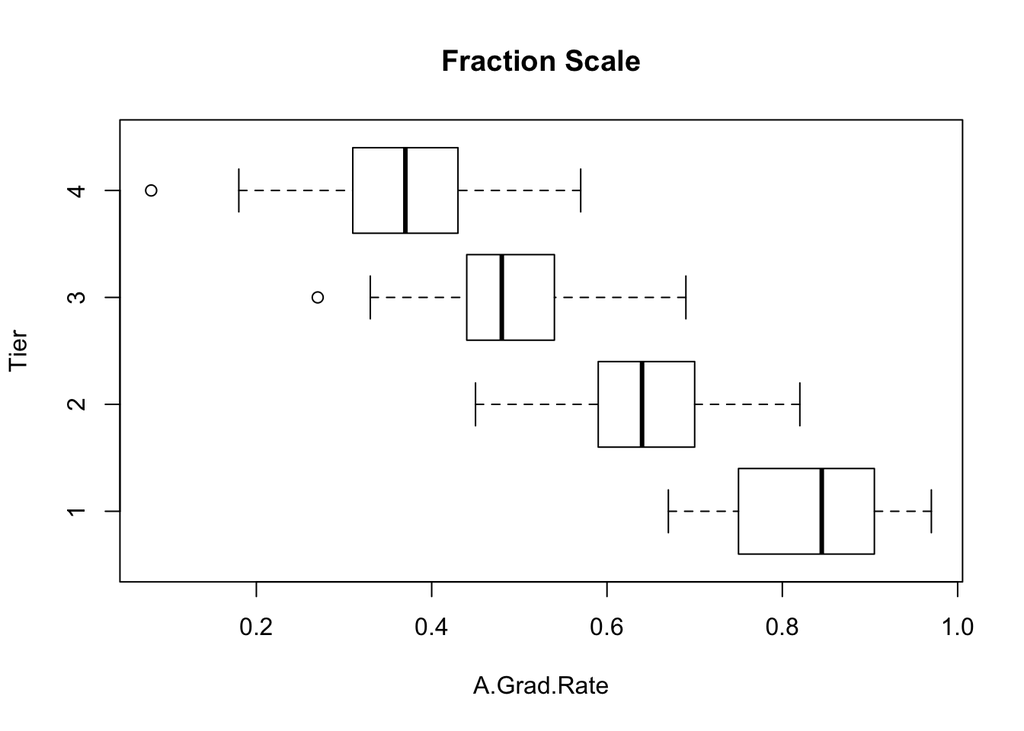

```r
boxplot(a.grad.rate ~ Tier, data=college.ratings,
        horizontal=TRUE, main="Fraction Scale",
        xlab="A.Grad.Rate", ylab="Tier")
```

Since IQR seems to be approximately equalized spreads except the Tier 1, we might not need to reexpress the data.

we need to use the summarize function in the dplyr package and compare the interquartile range of a.grad.rate for each tier.

```r
library(dplyr)
summarize(group_by(college.ratings, Tier),
          IQR=IQR(a.grad.rate, na.rm=TRUE)) #na.rm means "logical. Should missing values be removed?""
```

```
## # A tibble: 4 × 2
##    Tier    IQR
##   <int>  <dbl>
## 1     1 0.1525
## 2     2 0.1100
## 3     3 0.1000
## 4     4 0.1175
```

Tier 2, 3 and 4 have the similar value of IQR. We see that the spread of the Tier 1 values ($0.1525$) is about 1.386364 times larger than the spread of the Tier 2 values ($0.11$).

If we focus on comparisons between tiers 2, 3, and 4, it appears that this seems pretty good for equalizing spreads.

```r
summarize(group_by(college.ratings, Tier),
          M=median(a.grad.rate, na.rm=TRUE))
```

```
## # A tibble: 4 × 2
##    Tier     M
##   <int> <dbl>
## 1     1 0.845
## 2     2 0.640
## 3     3 0.480
## 4     4 0.370
```

On the fraction scale,the Tier 2 “a.grad.rate” fractions tend to be $0.64 - 0.48 = 0.16$ higher than the Tier 3 fractions. Similarly, the Tier 3 “a.grad.rate” fractions tend to be $0.480 - 0.370 = 0.11$ higher than the Tier 4 fractions.

Next, let’s see the effect of transformating the a.grad.rate variable to the froot and flog scales.

**Comparing the froots of the variable across tiers.**

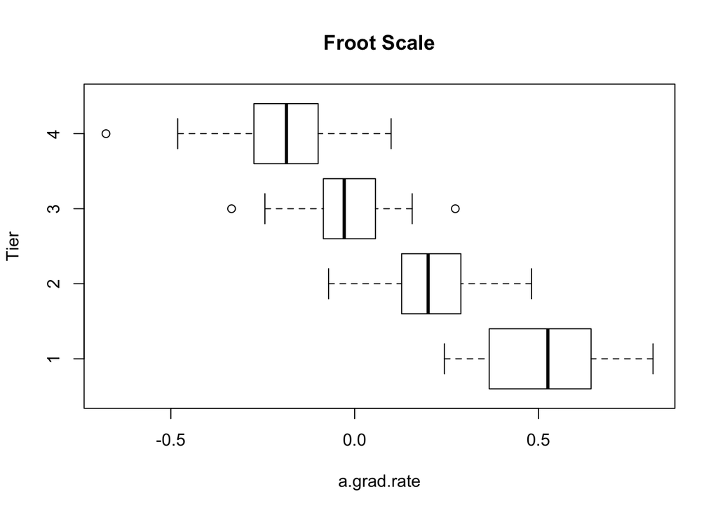

```r
froot <- function(p) sqrt(p) - sqrt(1- p)

boxplot(froot(a.grad.rate) ~ Tier, data=college.ratings,
        horizontal=TRUE, main="Froot Scale",
        xlab="a.grad.rate", ylab="Tier")
```

```r
summarize(group_by(college.ratings, Tier),
          IQR=IQR(froot(a.grad.rate), na.rm=TRUE))
```

```
## # A tibble: 4 × 2
##    Tier       IQR
##   <int>     <dbl>
## 1     1 0.2718010
## 2     2 0.1611353
## 3     3 0.1416204
## 4     4 0.1710804
```

We can see that there are three outliers among the Tiers. Comareing the IQR, we can see the IQR have larger spreads so reexpressions does not help in equalizing spread.

**Comparing the flogs of the variable across tiers.**

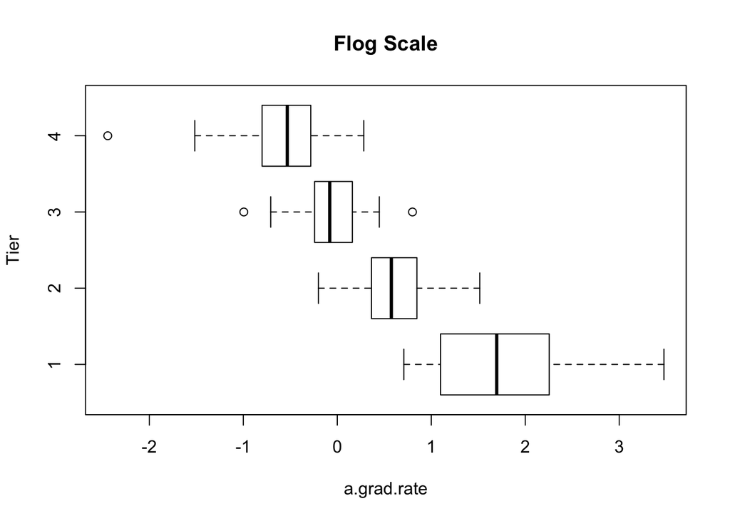

```r
flog <- function(p) log(p) - log(1 - p)

boxplot(flog(a.grad.rate) ~ Tier, data=college.ratings,
        horizontal=TRUE, main="Flog Scale",
        xlab="a.grad.rate", ylab="Tier")
```

```r
summarize(group_by(college.ratings, Tier),
          IQR=IQR(flog(a.grad.rate), na.rm=TRUE))
```

```
## # A tibble: 4 × 2
##    Tier       IQR
##   <int>     <dbl>
## 1     1 1.1277149
## 2     2 0.4833325
## 3     3 0.4015047
## 4     4 0.5080376
```

If we focus again on comparisons between tiers 2, 3, and 4, it appears that the flog expression is good for equalizing spreads. However, the fraction variable across tiers is better for equalizing spreads than the flog expression if we focus on comparisons between tiers 2, 3, and 4.

Is it necessary to reexpress the data by froots or flogs in this example?

It is not necessary to reexpress the data since the the fraction variable across tiers has the best equalized spreads (original data).

#### 2. Think of a second variable that you think will distinguish these four groups of colleges. (Explain why you chose this variable.) For the variable that you chose, compare the four tiers of schools using stemplots, parallel boxplots, and any needed reexpression. How do the tiers compare with respect to the variable? Are there unusual schools with respect to the variable?

I think that F.retention will distinguish these four groups of college since students should continue at the university which has a good program. On the other hand, the universities which are in lower tiers should have a lower F.retention.

*(Retention rate is the percentage of a school’s first-time, first-year undergraduate students who continue at that school the next year. For example, a student who studies full-time in the fall semester and keeps on studying in the program in the next fall semester is counted in this rate.)*

**Using stemplots and histogram** For the Tier 1

```r
s1 <- subset(college.ratings,Tier==1)
x <- aplpack::stem.leaf(s1$F.retention)
```

```
## 1 | 2: represents 0.012
##  leaf unit: 0.001
##             n: 52
## LO: 0.84 0.85
##    4    87 | 00
##    5    88 | 0
##    7    89 | 00
##    9    90 | 00
##   12    91 | 000
##   18    92 | 000000
##   21    93 | 000
##   (8)   94 | 1010101010101010
##   23    95 | 00
##   21    96 | 00000000000
##   10    97 | 0000
##    6    98 | 00000
##    1    99 | 0
```

From both the stemplot and the histogram, we can see that the data is not symmetric. The data is skewed left. Also we can see the data distribution in the low end has smaller frequency. There are two lower extreme values (Yeshiva_University, Tulane_University).

For the Tier 2

```r
s2 <- subset(college.ratings,Tier==2)
x <- aplpack::stem.leaf(s2$F.retention)
```

```
## 1 | 2: represents 0.012
##  leaf unit: 0.001
##             n: 78
## LO: 0.73
##    4    77 | 000
##    6    78 | 00
##    8    79 | 00
##    9    80 | 0
##   14    81 | 00000
##   20    82 | 000000
##   30    83 | 0000000000
##   39    84 | 000000000
##   (6)   85 | 000000
##   33    86 | 000000000
##   24    87 | 000000
##   18    88 | 0000000
##   11    89 | 0000
##    7    90 | 000
##    4    91 | 0000
```

For the Tier 3

```r
s3 <- subset(college.ratings,Tier==3)
x <- aplpack::stem.leaf(s3$F.retention)
```

```
## 1 | 2: represents 0.12
##  leaf unit: 0.01
##             n: 57
##     1     t | 2
##     3     f | 55
##           s |
##          6. |
##     8    7* | 111110
##    15     t | 2333333
##    23     f | 44445555
##   (12)    s | 666677777777
##    22    7. | 88888999999
##    11    8* | 00001
##     6     t | 2333
##     2     f | 44
```

We can see that the data is not symmetric. The data is slightly skewed left. There are one gap. We see that most of the F.retention in Tier 3 fall between 0.76 and 0.80.

For the Tier 4

```r
s4 <- subset(college.ratings,Tier==4)
x <- aplpack::stem.leaf(s4$F.retention)
```

```
## 1 | 2: represents 0.12
##  leaf unit: 0.01
##             n: 62
##    2    5. | 88
##    5    6* | 101010
##   10     t | 22223
##   13     f | 445
##   17     s | 6777
##   23    6. | 888999
##   (9)   7* | 1111110101010
##   30     t | 222222333
##   21     f | 444555555
##   12     s | 6667777
##    5    7. | 899
##         8* |
##    2     t | 3
##    1     f | 5
```

There are one isolated cluster at the high end. The data is roughly symmetric. We see that most of the F.retention in Tier 4 fall between 0.71 and 0.75.

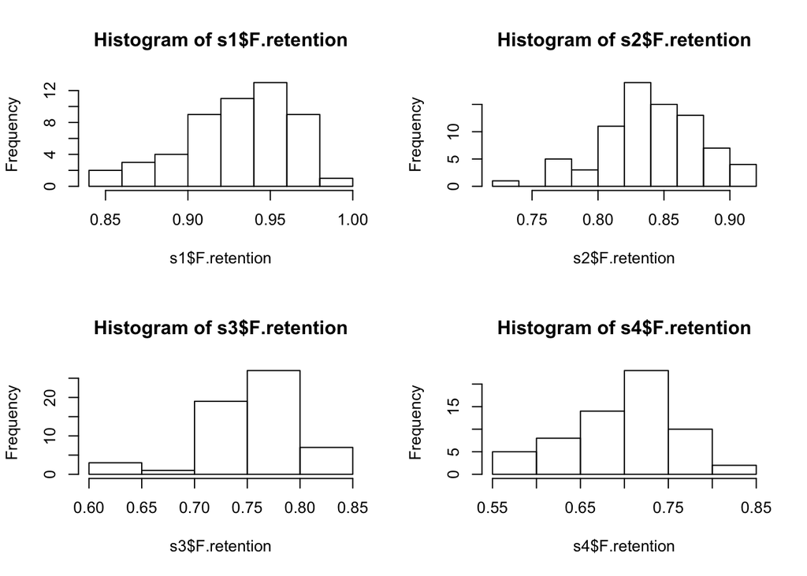

```r
par(mfrow=c(2,2))
hist(s1$F.retention)
hist(s2$F.retention)
hist(s3$F.retention)
hist(s4$F.retention)
```

Overall, the Tier 2 and the Tier 4 are roughly symmetric. However, the Tier 1 and the Tier 3 are skewed left.

**Comparing the fraction variable across tiers.**

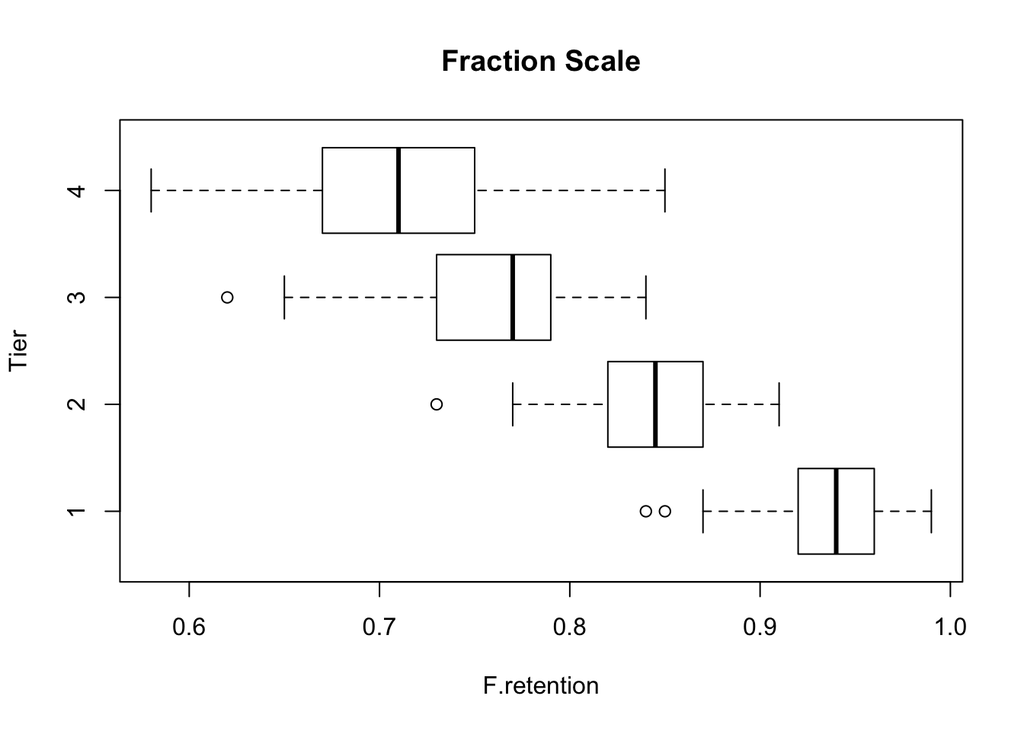

```r
boxplot(F.retention ~ Tier, data=college.ratings,
        horizontal=TRUE, main="Fraction Scale",
        xlab="F.retention", ylab="Tier")
```

```r
summarize(group_by(college.ratings, Tier),
          IQR=IQR(F.retention, na.rm=TRUE)) #na.rm means "logical. Should missing values be removed?""
```

```
## # A tibble: 4 × 2
##    Tier    IQR
##   <int>  <dbl>
## 1     1 0.0400
## 2     2 0.0475
## 3     3 0.0600
## 4     4 0.0800
```

It is difficult to compare these F.retention rates due to the difference in variability across tiers. In particular, the Tier 4 has the larger interquartile range of F.retention for each tier compare to others. The Tier 1 and 2 have similar spreads.However, we need to reexpress the data.

**Comparing the froots of the variable across tiers.**

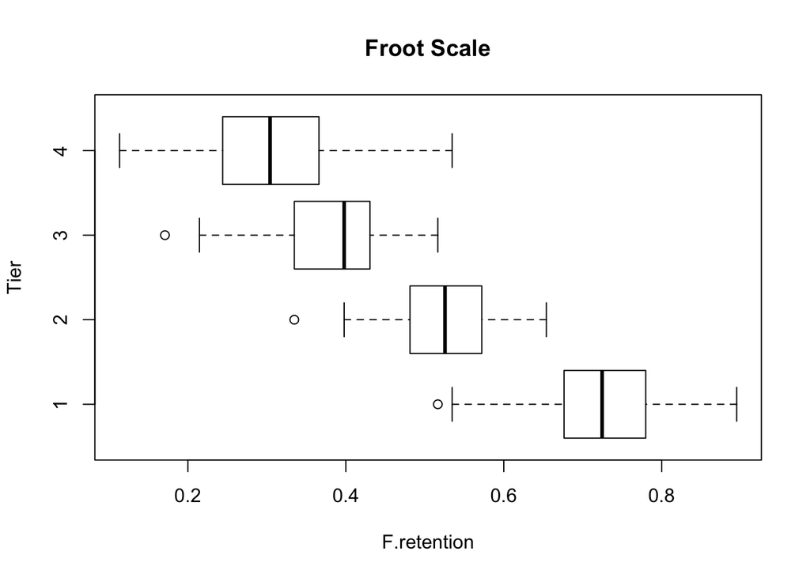

```r
froot <- function(p) sqrt(p) - sqrt(1- p)

boxplot(froot(F.retention) ~ Tier, data=college.ratings,
        horizontal=TRUE, main="Froot Scale",
        xlab="F.retention", ylab="Tier")
```

```r
summarize(group_by(college.ratings, Tier),
          IQR=IQR(froot(F.retention), na.rm=TRUE))
```

```
## # A tibble: 4 × 2
##    Tier        IQR
##   <int>      <dbl>
## 1     1 0.10347230
## 2     2 0.08654375
## 3     3 0.09577674
## 4     4 0.12194639
```

We can see that the IQR seems to be approximately equalized spreads. This is the best if we focus on comparisons between tiers 1, 2, 3, and 4.

If look at the ratio of the largest IQR to the smallest IQR, then we compute the ratio $1.409072$ for froots.

We see that the spread of the Tier 1 values ($0.10347230$) is about $1.195607$ times larger than the spread of the Tier 2 values ($0.08654375$). Likewise, the spread of the Tier 4 values ($0.12194639$) is about $1.273236$ times larger than the spread of the Tier 3 values ($0.09577674$).

```r
data <- data.frame(college.ratings[,c(2,5)])
tier1 <- data[which(data[,1]==1),][,2]
tier2 <- data[which(data[,1]==2),][,2]
tier3 <- data[which(data[,1]==3),][,2]
tier4 <- data[which(data[,1]==4),][,2]
aplpack::stem.leaf(froot(tier1))
```

```
## 1 | 2: represents 0.12
##  leaf unit: 0.01
##             n: 52
##    2    5* | 13
##    5    5. | 779
##    9    6* | 1133
##   21    6. | 555777777999
##   (8)   7* | 22222222
##   23    7. | 5577777777777
##   10    8* | 111144444
##    1    8. | 9
```

```r
aplpack::stem.leaf(froot(tier2))
```

```
## 1 | 2: represents 0.12
##  leaf unit: 0.01
##             n: 78
##    1     t | 3
##          f |
##          s |
##    4    3. | 999
##    6    4* | 11
##    8     t | 33
##    9     f | 4
##   14     s | 66666
##   30    4. | 8888889999999999
##   39    5* | 111111111
##   (6)    t | 333333
##   33     f | 555555555
##   24     s | 777777
##   18    5. | 9999999
##   11    6* | 1111
##    7     t | 333
##    4     f | 5555
```

```r
aplpack::stem.leaf(froot(tier3))
```

```
## 1 | 2: represents 0.12
##  leaf unit: 0.01
##             n: 57
## LO: 0.170959387104283
##     3    2* | 11
##           t |
##           f |
##           s |
##     4    2. | 8
##     9    3* | 00001
##    15     t | 333333
##    19     f | 5555
##    23     s | 6666
##   (12)   3. | 888899999999
##    22    4* | 11111
##    17     t | 333333
##    11     f | 4444
##     7     s | 6
##     6    4. | 8999
##     2    5* | 11
```

```r
aplpack::stem.leaf(froot(tier4))
```

```
## 1 | 2: represents 0.12
##  leaf unit: 0.01
##             n: 62
##     5    1* | 11444
##    10    1. | 77778
##    17    2* | 0012444
##    27    2. | 5557778888
##   (14)   3* | 00000111111333
##    21    3. | 5556666668889999
##     5    4* | 133
##     2    4. | 9
##     1    5* | 3
```

**Comparing the flogs of the variable across tiers.**

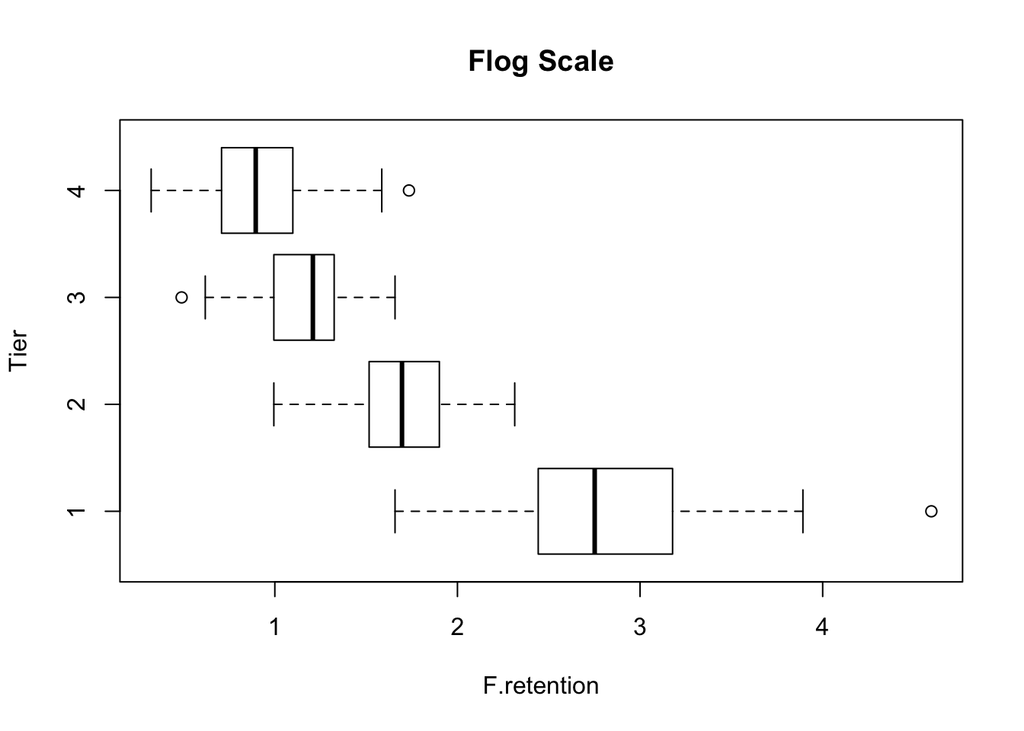

```r
flog <- function(p) log(p) - log(1 - p)

boxplot(flog(F.retention) ~ Tier, data=college.ratings,
        horizontal=TRUE, main="Flog Scale",
        xlab="F.retention", ylab="Tier")
```

```r
summarize(group_by(college.ratings, Tier),
          IQR=IQR(flog(F.retention), na.rm=TRUE))
```

```
## # A tibble: 4 × 2
##    Tier       IQR
##   <int>     <dbl>
## 1     1 0.7357068
## 2     2 0.3672913
## 3     3 0.3303028
## 4     4 0.3904272
```

If we focus on comparisons between tiers 2, 3, and 4, it appears that the flog expression is best for equalizing spreads. If look at the ratio of the largest IQR to the smallest IQR, then we compute the ratio $1.182028$ for flog. Therefore, this is the best reexpression, if we focus on comparisons between tiers 2, 3, and 4.

```r
summarize(group_by(college.ratings, Tier),
          M=median(flog(F.retention), na.rm=TRUE))
```

```
## # A tibble: 4 × 2
##    Tier        M
##   <int>    <dbl>
## 1     1 2.751535
## 2     2 1.696415
## 3     3 1.208311
## 4     4 0.895384
```

On the flog scale, the Tier 2 “F.retention” fractions tend to be $1.696415 - 1.208311 = 0.488104$ higher than the Tier 3 fractions. Similarly, the Tier 3 “F.retention” fractions tend to be $1.208311 - 0.895384 = 0.312927$ higher than the Tier 4 fractions.

The MEDIAN column gives the median change in flog for each Tier sequence. Therefore, the high ranked university has larger median.

```r
aplpack::stem.leaf(flog(tier1))
```

```
## 1 | 2: represents 1.2
##  leaf unit: 0.1
##             n: 52
##    2     s | 67
##    5    1. | 999
##    9    2* | 0011
##   12     t | 333
##   21     f | 444444555
##   (8)    s | 77777777
##   23    2. | 99
##   21    3* | 11111111111
##          t |
##   10     f | 4444
##          s |
##    6    3. | 88888
## HI: 4.59511985013459
```

```r
aplpack::stem.leaf(flog(tier2))
```

```
## 1 | 2: represents 0.12
##  leaf unit: 0.01
##             n: 78
##    1     9 | 9
##         10 |
##         11 |
##    6    12 | 00066
##    9    13 | 228
##   14    14 | 55555
##   30    15 | 1111118888888888
##   39    16 | 555555555
##   (6)   17 | 333333
##   33    18 | 111111111
##   24    19 | 0000009999999
##   11    20 | 9999
##    7    21 | 999
##         22 |
##    4    23 | 1111
```

```r
aplpack::stem.leaf(flog(tier3))
```

```
## 1 | 2: represents 0.12
##  leaf unit: 0.01
##             n: 57
## LO: 0.489548225318706
##    3     6 | 11
##          7 |
##    8     8 | 49999
##   15     9 | 4999999
##   23    10 | 44449999
##   (4)   11 | 5555
##   30    12 | 0000000066666
##   17    13 | 2222228888
##    7    14 | 5
##    6    15 | 1888
##    2    16 | 55
```

```r
aplpack::stem.leaf(flog(tier4))
```

```
## 1 | 2: represents 0.12
##  leaf unit: 0.01
##             n: 62
##     2     3 | 22
##     9     4 | 0008888
##    12     5 | 377
##    14     6 | 16
##    20     7 | 000555
##   (12)    8 | 000444499999
##    30     9 | 444444999
##    21    10 | 444999999
##    12    11 | 555
##     9    12 | 00006
##     4    13 | 22
##          14 |
##     2    15 | 8
## HI: 1.73460105538811
```

There are two higher extreme values and one lower exterme value among the Tier. Princeton_University, which is located in the Tier 1, has higher extreme value. Wayne_State_University, which is located in the Tier 3, has lower extreme value. Florida_International_University, which is located in the Tier4, has higher extreme value.

Are there unusual schools with respect to the variable? Yes, from stemplot, we could see that some schools have exterem values.